# Practical Lab 1 - Univariate Linear Regression on the California Housing Prices Dataset

## Goal Of The Report

- The main objective of this report is to build a univariate linear regression models to predict the median house value for houses in California. Model will evaluate relationship between dependent variable(median house value) and three independent variables(median income, population, and number of household). With this report, we aim to identify which one of the independent variables is the most ideal predictor of median house value which will help in providing valuable insights for decision-making in real estate business.

## Obtaining the Data

Source Source: Downloaded from [Kaggle California Housing Prices](https://www.kaggle.com/datasets/camnugent/california-housing-prices)

```python
import pandas as pd
import matplotlib.pyplot as plt
import seaborn as sns
import numpy as np

from sklearn import linear_model
from sklearn.metrics import mean_squared_error, mean_absolute_error
```

```python
data = pd.read_csv('../../data/housing.csv')
```

## Exploratory Data Analysis (EDA)

- To analyse and summarise data to know their main characteristics with visual representations.

### Description of data

```python
data.describe()
```

|  | longitude | latitude | housing_median_age | total_rooms | total_bedrooms | population | households | median_income | median_house_value |
| --- | --- | --- | --- | --- | --- | --- | --- | --- | --- |
| count | 20640.000000 | 20640.000000 | 20640.000000 | 20640.000000 | 20433.000000 | 20640.000000 | 20640.000000 | 20640.000000 | 20640.000000 |
| mean | -119.569704 | 35.631861 | 28.639486 | 2635.763081 | 537.870553 | 1425.476744 | 499.539680 | 3.870671 | 206855.816909 |
| std | 2.003532 | 2.135952 | 12.585558 | 2181.615252 | 421.385070 | 1132.462122 | 382.329753 | 1.899822 | 115395.615874 |
| min | -124.350000 | 32.540000 | 1.000000 | 2.000000 | 1.000000 | 3.000000 | 1.000000 | 0.499900 | 14999.000000 |
| 25% | -121.800000 | 33.930000 | 18.000000 | 1447.750000 | 296.000000 | 787.000000 | 280.000000 | 2.563400 | 119600.000000 |
| 50% | -118.490000 | 34.260000 | 29.000000 | 2127.000000 | 435.000000 | 1166.000000 | 409.000000 | 3.534800 | 179700.000000 |
| 75% | -118.010000 | 37.710000 | 37.000000 | 3148.000000 | 647.000000 | 1725.000000 | 605.000000 | 4.743250 | 264725.000000 |
| max | -114.310000 | 41.950000 | 52.000000 | 39320.000000 | 6445.000000 | 35682.000000 | 6082.000000 | 15.000100 | 500001.000000 |

- There are total 20640 observations in this dataset, in which total_bedroom has a fewer observations which indicates it has some missing values.
- This datasets shows substantial variability in most of the variables, including median_income, households and population.
- Median_house_value capped at 500001 indicates that data must be censored which can affect the predictibility of the model
- Standard deviation(1.899) of median_income is relatively high which suggests significant variation in income that indicates that it can be a strong predictor of median_house_value.

### Scatter plot: median_house_value vs median_income

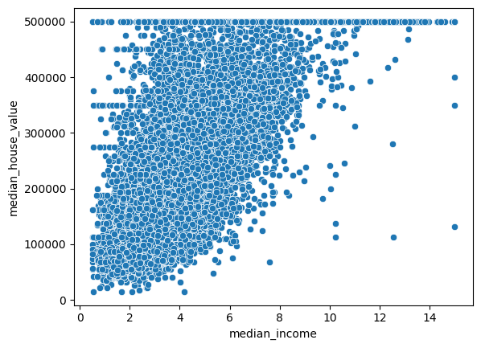

```python
sns.scatterplot(x="median_income", y="median_house_value", data=data)
```

- There is a visible positive correlation between median_income and median_house_value which means if median_income increases, median_house_value increases. Which makes median_income a strong predictor.
- The horizontal clustering line at 500001 shows that values have been capped at that value which might limit the prediction.
- A few outliers can be seen around 10 to 15 median_income levels.

### Scatter plot: median_house_value vs population

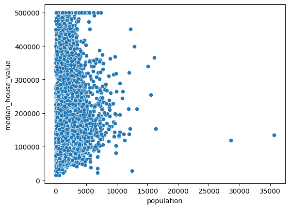

```python
sns.scatterplot(x="population", y="median_house_value", data=data)
```

- It does not indicate a strong linear relationship between population and median_house_value as the points are uniformly distributed across population sizes without significant upward or downward trend.
- Just like the previous scatter plot, house values are capped around 500000 which could limit the analysis for high-end houses.
- A few outliers can be seen at higher-end values of population.

### Scatter plot: median_house_value vs households

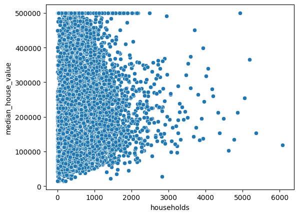

```python
sns.scatterplot(x="households", y="median_house_value", data=data)
```

- Similar to population plot, there is an absence of strong linear relationship between households and median_house_value. Wide spread of the data point without any significant trends suggests that households is not a reliable predictor of median_house_value.
- Capping is also present in this plot which can limit the analysis.
- There are a few outliers near 4000 to 6000 households values.

## Data Preprocessing

- Filtering out records capped at median_house_value = 500001 because they can limit the predictive ability of the model

```python
#Removing rows where median_house_value is capped
data = data[data['median_house_value'] < 500001]
```

- Removing outliers for all the independent variables using 1.5 IQR to increase the accuracy of the model

```python
def remove_outliers(df, column):
    Q1 = df[column].quantile(0.25)
    Q3 = df[column].quantile(0.75)
    IQR = Q3 - Q1
    lower_bound = Q1 - 1.5 * IQR
    upper_bound = Q3 + 1.5 * IQR
    return df[(df[column] >= lower_bound) & (df[column] <= upper_bound)]
```

```python
#Remove outliers for median_income
data = remove_outliers(data, 'median_income')

#Remove outliers for population
data = remove_outliers(data, 'population')

#Remove outliers for households
data = remove_outliers(data, 'households')
```

## Visualising the difference after Data Preprocessing steps using Seaborn Scatterplot

### Scatter plot: median_house_value vs median_income

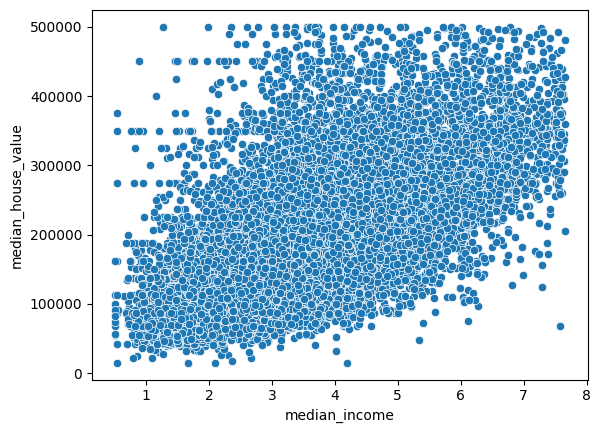

```python
sns.scatterplot(x="median_income", y="median_house_value", data=data)
```

### Scatter plot: median_house_value vs population

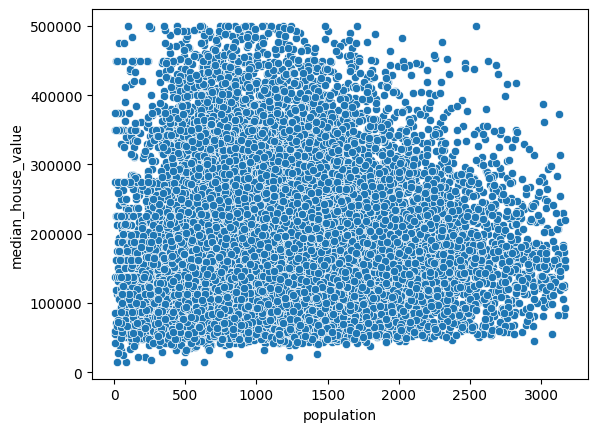

```python
sns.scatterplot(x="population", y="median_house_value", data=data)
```

### Scatter plot: median_house_value vs households

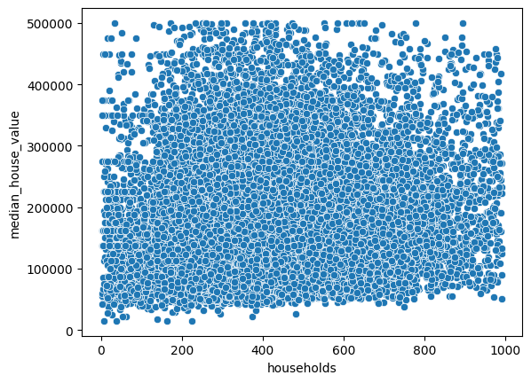

```python
sns.scatterplot(x="households", y="median_house_value", data=data)
```

## Train and Test Split

- Spliting the data into training and testing sets with 80:20 ratio.

```python
train_size = int(len(data) * 0.8)
train = data[:train_size]
test = data[train_size:]
```

### Visualisation of Training and Testing Split for median_house_value using Matplot Histogram

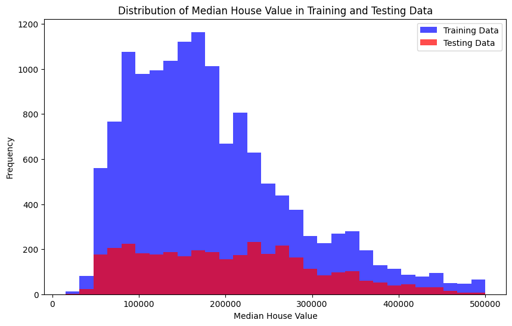

```python
plt.figure(figsize=(10, 6))
plt.hist(train['median_house_value'], bins=30, alpha=0.7, color='blue', label='Training Data')
plt.hist(test['median_house_value'], bins=30, alpha=0.7, color='red', label='Testing Data')
plt.title('Distribution of Median House Value in Training and Testing Data')
plt.xlabel('Median House Value')
plt.ylabel('Frequency')
plt.legend()
plt.show()
```

## Define The Models

- Creating Linear Regression objects for all 3 models

```python
model_income = linear_model.LinearRegression()
model_population = linear_model.LinearRegression()
model_households = linear_model.LinearRegression()
```

```python
#Fitting the models
model_income.fit(X=train[["median_income"]], y=train[["median_house_value"]])
model_population.fit(X=train[["population"]], y=train[["median_house_value"]])
model_households.fit(X=train[["households"]], y=train[["median_house_value"]])
```

```
LinearRegression()
```

```python
#Making predictions
y_pred_income = model_income.predict(test[["median_income"]])
y_pred_population = model_population.predict(test[["population"]])
y_pred_households = model_households.predict(test[["households"]])
```

```python
#Calculating MSE and MAE for each model
mse_income = mean_squared_error(test["median_house_value"], y_pred_income)
mae_income = mean_absolute_error(test["median_house_value"], y_pred_income)

mse_population = mean_squared_error(test["median_house_value"], y_pred_population)
mae_population = mean_absolute_error(test["median_house_value"], y_pred_population)

mse_households = mean_squared_error(test["median_house_value"], y_pred_households)
mae_households = mean_absolute_error(test["median_house_value"], y_pred_households)
```

```python
#Extracting intercepts and slopes
intercept_income = model_income.intercept_
slope_income = model_income.coef_[0]

intercept_population = model_population.intercept_
slope_population = model_population.coef_[0]

intercept_households = model_households.intercept_
slope_households = model_households.coef_[0]
```

```python
#Creating a summary DataFrame(table)
prediction_results = pd.DataFrame({
    'Model': ['Median Income', 'Population', 'Number of Households'],
    'Intercept': [intercept_income, intercept_population, intercept_households],
    'Slope': [slope_income, slope_population, slope_households],
    'MSE': [mse_income, mse_population, mse_households],
    'MAE': [mae_income, mae_population, mae_households]
})

prediction_results
```

|  | Model | Intercept | Slope | MSE | MAE |
| --- | --- | --- | --- | --- | --- |
| 0 | Median Income | [43307.24020782497] | [39849.5400198137] | 5.694653e+09 | 59511.419921 |
| 1 | Population | [187936.28682790973] | [-3.693177879088391] | 1.058620e+10 | 84609.553028 |
| 2 | Number of Households | [159501.148660461] | [57.85480988132887] | 1.041721e+10 | 83387.021594 |

### Model Interpretation:

1. Median Income Model:
- Intercept: 43,307.24, which means when the median_income is 0, the predicted median_house_value is approx. $43,307.
- Slope: 39,849.54, suggesting that for each 1 unit increase in median_income (1 unit = 10,000$), the median_house_value increases by $39,849.
- MSE and MAE: This model has the lowest MSE which is 5.69e+09 and MAE, 59,511, indicating that it provides the most accurate predictions out of the three models.
2. Population Model:
- Intercept: 187,936.29, indicating that the predicted median_house_value is around $187,936 when the population is 0.
- Slope: -3.69, shows that for every 1 person increase in population, the median_house_value decreases by $3.69.
- MSE and MAE: This model has the highest MSE (1.06e+10) and MAE (84,609), that proves it performs poorly in predicting house prices based on population.
3. Number of Households Model:
- Intercept: 159,501.15, that means when the number of households is 0, the predicted median_house_value is approx. $159,501.
- Slope: 57.85, showing that for every 1 household increase, the median_house_value increases by about $57.85.
- MSE and MAE: This model has a bit better performance than the population model but it is still less accurate than the median income model.

## Plotting Regression Line with Scatter Data

```python
def plot_regression_with_metrics(train_data, test_data, train_pred, test_pred, title, intercept, slope, mse, mae, x_var, y_var):
    plt.figure(figsize=(10, 6))

    #Scatter plot for the training data
    sns.scatterplot(x=x_var, y=y_var, data=train_data, color="blue", label="Train Data")
    plt.plot(train_data[[x_var]], train_pred, color="black", linewidth=3, label="Train Regression Line")

    #Scatter plot for the testing data
    sns.scatterplot(x=x_var, y=y_var, data=test_data, color="orange", label="Test Data")
    plt.plot(test_data[[x_var]], test_pred, color="red", linewidth=3, label="Test Regression Line")

    #Title and labels
    plt.title(title)
    plt.xlabel(x_var)
    plt.ylabel(y_var)

    intercept = intercept[0] if isinstance(intercept, np.ndarray) else intercept
    slope = slope[0] if isinstance(slope, np.ndarray) else slope

    #Adding text box with model parameters (Intercept, Slope, MSE, MAE)
    textstr = f'Intercept: {intercept:.2f}\nSlope: {slope:.2f}\nMSE: {mse:.2e}\nMAE: {mae:.2f}'
    plt.gca().text(0.05, 0.95, textstr, transform=plt.gca().transAxes,
                   fontsize=12, verticalalignment='top', bbox=dict(boxstyle="round", facecolor='wheat', alpha=0.5))

    plt.legend()
    plt.show()
```

- Created this function for regression line with labels and text box with model parameters using [Chatgpt](https://chatgpt.com/).

### Median income model

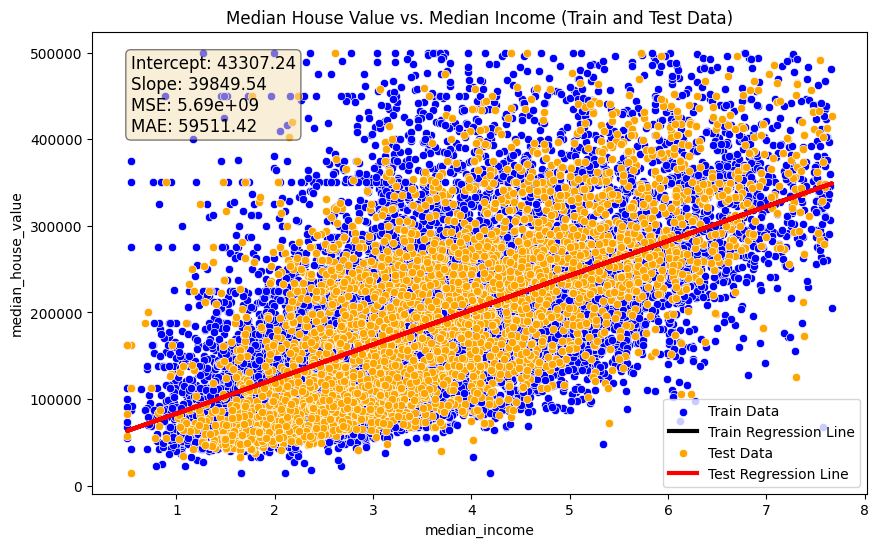

```python
train_pred_income = model_income.predict(train[["median_income"]])
test_pred_income = model_income.predict(test[["median_income"]])

plot_regression_with_metrics(train, test, train_pred_income, test_pred_income,
                             "Median House Value vs. Median Income (Train and Test Data)",
                             intercept_income, slope_income, mse_income, mae_income,
                             "median_income", "median_house_value")
```

### Population Model

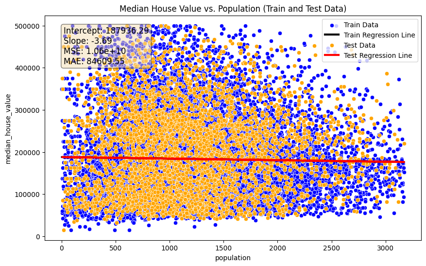

```python
train_pred_population = model_population.predict(train[["population"]])
test_pred_population = model_population.predict(test[["population"]])

plot_regression_with_metrics(train, test, train_pred_population, test_pred_population,
                             "Median House Value vs. Population (Train and Test Data)",
                             intercept_population, slope_population, mse_population, mae_population,
                             "population", "median_house_value")
```

### Household Model

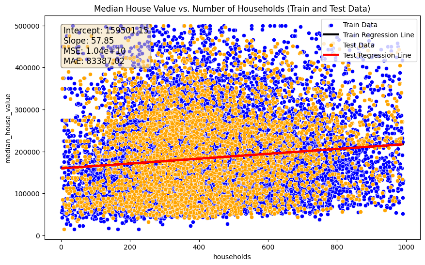

```python
train_pred_households = model_households.predict(train[["households"]])
test_pred_households = model_households.predict(test[["households"]])

plot_regression_with_metrics(train, test, train_pred_households, test_pred_households,
                             "Median House Value vs. Number of Households (Train and Test Data)",
                             intercept_households, slope_households, mse_households, mae_households,
                             "households", "median_house_value")
```

# Conclusion and Insights

The Median income model however is the one that has the best goodness of fit while predicting the price of the houses since it recorded lower MSE and MAE as opposed to Population and Number of Households models that have weak association and higher error metrics leading to poor prediction accuracy.

Model Comparison (Goodness-of-Fit):

- Median Income: This is the best model which possess a high degree of correlation towards the dependent variable and having the least error values (MSE: 5.69e+09, MAE: 59,511) that portrays the strongest linear relationship connection between income and house prices.
- Population: This was rather disappointing as the model performed the worst registering a rather flat or even downward facing curve against the range of variables of house prices (MSE: 1.06e+10, MAE: 84,610) which led to the conclusion that population size is not a useful indicator of house prices.
- Number of Households: This was a shade better than the population however a very weak predictor (MSE: 1.04e+10, MAE: 83,387) with only the slightest positive slope indicating minimal influences on the prices of houses.

Insights:

- The Median Income model clearly demonstrates that income levels are an obvious influencer of house prices, whereas Population and Number of Households might be more complex in their modeling or might need more features to help explain their effect on housing prices.